# Project 4 -- Linear Regression

## Part 1 - Getting Started

In this project, we are going to design a mathematical model that predicts electrical grid stability, as described in the paper below:

*Schäfer, Benjamin, et al. 'Taming instabilities in power grid networks by decentralized control.' The European Physical Journal Special Topics 225.3 (2016): 569-582.*

For this purpose, we are using the [Electrical Grid Stability](https://archive.ics.uci.edu/dataset/471/electrical+grid+stability+simulated+data) dataset which includes 10000 instances with 12 features describing the power grid's status. The goal is to unravel patterns and predict the `stab` column, which is a characteristic of the grid that represents its stability. Note that you can ignore the last column named `stabf` since this is a binary indicator showing whether the stability is above a certain threshold.

```python
import pandas as pd
df = pd.read_csv(
    filepath_or_buffer="https://raw.githubusercontent.com/Sabaae/Dataset/main/electrical_grid_stability_simulated_data.csv",
    skipinitialspace=True
)
```

Here are the steps to complete this portion:

1. Print the dataframe.
2. Prepare your dataset as follows:
- Using `train_test_split` from Sklearn, split the dataset into training and validation sets ($80\%$ training, $20\%$ validation). When splitting, set `random_state=111`.
- Standardize the data **manually** according to the same method as `StandardScaler` from sklearn, but you may not directly use `StandardScaler'.
- Insert a first column of all $1$s in both the training and validation data sets.
3. Explain why we should not insert the column of $1$s prior to standardization.

The column of 1's is defined as a bias term and is not one of the features. Standardizing it would create unexpected values and affect the standardization of other features, so it should be added after standardization.

```python
from sklearn.model_selection import train_test_split
import numpy as np

print(df)

X = df.drop(columns=['stab', 'stabf'])
y = df['stab']

# 80% training, 20% validation
X_train, X_valid, y_train, y_valid = train_test_split(X, y, test_size=0.2, random_state=111)

# standardize data
mean_train = X_train.mean(axis=0)
std_train = X_train.std(axis=0)
X_train_std = (X_train - mean_train) / std_train
X_valid_std = (X_valid - mean_train) / std_train

# insert a column of all 1s in both train and validation datasets
one_train = np.ones(np.shape(X_train_std)[0]).reshape(-1, 1)
one_valid = np.ones(np.shape(X_valid_std)[0]).reshape(-1, 1)
X_train_1f = np.hstack((one_train, X_train_std))
X_valid_1f = np.hstack((one_valid, X_valid_std))

X_train_1f[0:10]
```

```
          tau1      tau2      tau3      tau4        p1        p2        p3  \
0     2.959060  3.079885  8.381025  9.780754  3.763085 -0.782604 -1.257395
1     9.304097  4.902524  3.047541  1.369357  5.067812 -1.940058 -1.872742
2     8.971707  8.848428  3.046479  1.214518  3.405158 -1.207456 -1.277210
3     0.716415  7.669600  4.486641  2.340563  3.963791 -1.027473 -1.938944
4     3.134112  7.608772  4.943759  9.857573  3.525811 -1.125531 -1.845975
...        ...       ...       ...       ...       ...       ...       ...
9995  2.930406  9.487627  2.376523  6.187797  3.343416 -0.658054 -1.449106
9996  3.392299  1.274827  2.954947  6.894759  4.349512 -1.663661 -0.952437
9997  2.364034  2.842030  8.776391  1.008906  4.299976 -1.380719 -0.943884
9998  9.631511  3.994398  2.757071  7.821347  2.514755 -0.966330 -0.649915
9999  6.530527  6.781790  4.349695  8.673138  3.492807 -1.390285 -1.532193

            p4        g1        g2        g3        g4      stab     stabf
0    -1.723086  0.650456  0.859578  0.887445  0.958034  0.055347  unstable
1    -1.255012  0.413441  0.862414  0.562139  0.781760 -0.005957    stable
2    -0.920492  0.163041  0.766689  0.839444  0.109853  0.003471  unstable
3    -0.997374  0.446209  0.976744  0.929381  0.362718  0.028871  unstable
4    -0.554305  0.797110  0.455450  0.656947  0.820923  0.049860  unstable
...        ...       ...       ...       ...       ...       ...       ...
9995 -1.236256  0.601709  0.779642  0.813512  0.608385  0.023892  unstable
9996 -1.733414  0.502079  0.567242  0.285880  0.366120 -0.025803    stable
9997 -1.975373  0.487838  0.986505  0.149286  0.145984 -0.031810    stable
9998 -0.898510  0.365246  0.587558  0.889118  0.818391  0.037789  unstable
9999 -0.570329  0.073056  0.505441  0.378761  0.942631  0.045263  unstable

[10000 rows x 14 columns]
```

```
array([[ 1.        , -1.66052809,  0.43069452,  0.37752111, -1.6260303 ,
        -1.10423793,  0.14079159,  1.29472067,  0.48586724, -0.1836897 ,
        -1.69964322, -1.11206846,  0.44410138],
       [ 1.        ,  1.66166859,  0.15738785,  0.90784343, -0.05768646,
        -1.23390159,  1.42494006,  0.43719056,  0.28036845,  0.79356593,
        -1.20449062,  0.27208366, -0.45009929],
       [ 1.        ,  0.5662664 , -1.40938907, -0.76573269, -0.02276752,
         1.61981527, -0.65797522, -1.2294227 , -0.93005116,  1.40013118,
        -1.37395294,  0.37058962, -1.73678628],
       [ 1.        ,  0.81763929,  1.39060986, -0.22046839,  1.04271297,
        -0.25310298,  1.44432141,  0.39086583, -1.40200859,  1.42429113,
         0.7545228 ,  0.27258767,  1.57751642],
       [ 1.        ,  1.46522503, -0.80301378, -1.67700395,  0.08550613,
         0.2940314 , -0.75883091, -1.40402328,  1.65676413,  0.32762917,
        -0.97096391,  0.29428122, -0.9451889 ],
       [ 1.        , -1.25575854, -0.79205776,  0.44203851, -0.69740738,
        -0.19002428, -1.40398244,  0.98756188,  0.75280616,  0.45189459,
         1.57272429, -0.20962636, -0.96878729],
       [ 1.        ,  1.15356828,  0.51215967,  0.41687511, -0.72604703,
         1.16829143, -0.67173382, -1.73300973,  0.37518077, -0.74094097,
         0.09383609, -1.64178887, -0.28619181],
       [ 1.        ,  1.12412995,  0.16573904,  1.31709798,  0.58653922,
        -0.06388676,  0.33313518,  1.03716666, -1.26250926,  1.43567576,
         0.5715976 , -0.29054894, -1.38540643],
       [ 1.        ,  0.15080565, -0.96687151, -0.33120859, -0.82231033,
         2.06247903, -0.65189263, -1.65182798, -1.28445332,  0.68526036,
         1.49927637,  1.52415978,  1.00904833],
       [ 1.        , -0.25232407,  1.50845275,  1.15582667,  1.5361323 ,
        -0.01076051,  0.12424483, -1.28790103,  1.18412834,  0.31546524,
         1.44455887, -0.06311283, -1.38767709]])
```

## Part 2 - Linear Regression Using Direct Solution

Implement the direct solution of the linear regression problem on the training set.

**Note: You should use scipy.linalg.inv to perform the inversion, as numpy.linalg.inv may cause an error.**

Report the root-mean-square error (RMSE) for both the training and validation sets.

RMSE for training set: 0.0220

RMSE for validation set: 0.0218

You may use `root_mean_squared_error` from Sklearn for computing the RMSE.

```
RMSE on training set: 0.0220
RMSE on validation set: 0.0218
```

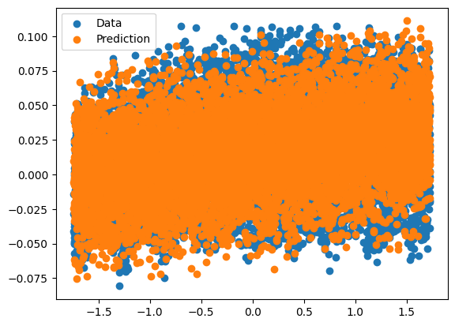

```python
from sklearn.metrics import mean_squared_error
import matplotlib.pyplot as plt
import scipy

def rmse(yPred, y):
    return np.sqrt(mean_squared_error(yPred, y))

def Direct_sol(X_train, y_train, X_valid, y_valid):
    W = np.dot(scipy.linalg.inv(np.dot(X_train.T, X_train)), np.dot(X_train.T, y_train))

    y_pred_train = np.dot(X_train, W)
    y_pred_valid = np.dot(X_valid, W)
    RMSE_train = rmse(y_pred_train, y_train)
    RMSE_valid = rmse(y_pred_valid, y_valid)

    plt.scatter(X_train[:, 1], y_train, label='Data')
    plt.scatter(X_train[:, 1], y_pred_train, label='Prediction')
    print (f"RMSE on training set: {RMSE_train:.4f}")
    print (f"RMSE on validation set: {RMSE_valid:.4f}")
    plt.legend()
    plt.show()

    return W, y_pred_train, y_pred_valid, RMSE_train, RMSE_valid

result = Direct_sol(X_train_1f, y_train, X_valid_1f, y_valid)
```

## Part 3 - Full Batch Gradient Descent

We will now implement a "full batch" gradient descent algorithm and record the training time for our model. Recall that the full batch gradient descent is, $$w_t = w_{t-1} - \alpha~g_t$$ where $\alpha$ is the learning rate and $g_t$ is your gradient, computed on the entire data.

Here are the steps for this part:

- Implement gradient descent for linear regression using a fixed learning rate of $\alpha= 0.01$, and iterate until your model's **validation** RMSE converges.

  We consider the gradient descent as having converged when RMSE on the validation set using gradient descent satisfies:

  $$ RMSE_\text{GD} \leq 1.0005 \times RMSE_\text{Direct Solution}$$

  where $RMSE_\text{Direct Solution}$ is the RMSE on the validation set using the direct solution that you calculated in the previous part.

  We refer to the quantity $RMSE_\text{Direct Solution}\times 1.0005$ as the convergence threshold (CT). Be sure to compute the gradients yourself! Take a look at the code provided in the tutorial.
- Record the training time (from the first iteration until convergence) using the `time.time()` function.
- Plot the training RMSE and the validation RMSE vs. epoch on the same figure.
- Comment on overfitting/underfitting by observing the training and validation RMSE

  **Hint**: Initialize your weights with small random numbers (<$0.00001$) & please set **np.random.seed(1001)**

  The RMSE vs Epoch plot shows both training and validation RMSE decreasing smoothly, indicating a good fit to the dataset without significant overfitting or underfitting. The alignment of the two curves suggests that the model generalizes well for both existing and unseen data. With the validation RMSE converging at epoch 351, it demonstrates an efficient convergence with small initial weights and learning rate of 0.01. These parameters help the model to converge faster, revealing a significant parameter tuning and training process.
- Explain the difference between epoch and iteration in the Gradient descent algorithm (SGD/mini-batch)?

  Eepoch is a complete loop of the entire training dataset, whereas iteration is a single update of the model parameters. The number of iterations in an epoch depends on the batch size. Smaller batch sizes result in more iterations per epoch because more batches are required to process the entire dataset. In gradient descent, each iteration processes a mini-batch, so it needs multiple iterations to complete one epoch.

```
RMSE on training set: 0.0220
RMSE on validation set: 0.0218
```

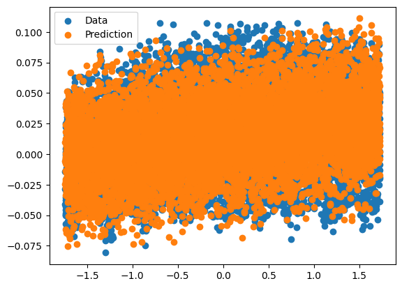

```
Initial weight: [[3.06232180e-06 2.65063566e-06 1.96060063e-06 4.30521477e-06
  2.31135520e-07 1.95781915e-06 3.52805288e-06 2.23242019e-06
  6.13521856e-06 5.80457112e-06 8.53567679e-06 4.11305365e-07
  4.88174437e-06]]
Validation RMSE converges at epoch 351
Final weights: [[ 1.55772660e-02  9.56921810e-03  1.01929401e-02  9.90765493e-03
   1.00198754e-02 -6.01667136e-05  2.38845546e-04  3.96240835e-04
  -5.16812552e-04  1.00909759e-02  1.02756047e-02  1.08288711e-02
   1.00614224e-02]]
--- Total Training Time: 0.668626070022583 (s) ---
```

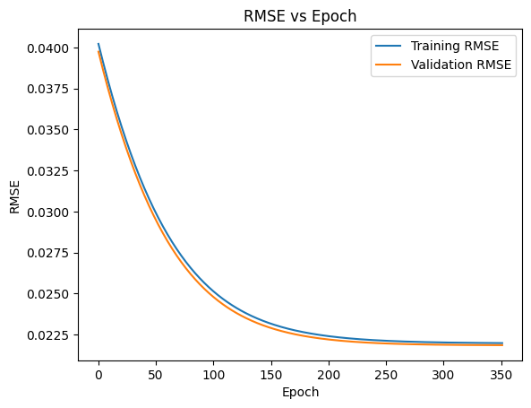

```python
import time

start_time = time.time() ## Records current time
np.random.seed(1001)

W, y_pred_train, y_pred_valid, RMSE_train, RMSE_valid = Direct_sol(X_train_1f, y_train, X_valid_1f, y_valid)

w = np.random.rand(X_train_1f.shape[1]).reshape(1, -1) * 1e-5 # initial weight
print(f"Initial weight: {w}")
lr = 0.01 # learning rate

# record rmse values
rmse_train_array = []
rmse_valid_array = []

for epoch in range(5000):
    y_train_pred = np.dot(X_train_1f, w.T).reshape(-1, 1)
    y_valid_pred = np.dot(X_valid_1f, w.T).reshape(-1, 1)

    curr_rmse_train = rmse(y_train_pred, y_train)
    curr_rmse_valid = rmse(y_valid_pred, y_valid)

    rmse_train_array.append(curr_rmse_train)
    rmse_valid_array.append(curr_rmse_valid)

    gradient = (1 / len(y_train_pred) * np.dot(X_train_1f.T, y_train_pred - y_train.to_numpy().reshape(-1, 1))).reshape(1, -1)
    w = w - lr * gradient

    if curr_rmse_valid <= RMSE_valid * 1.0005:
        print(f"Validation RMSE converges at epoch {epoch}")
        break

print(f"Final weights: {w}")

print("--- Total Training Time: %s (s) ---" % (time.time() - start_time))

# plot RMSE vs Epoch
plt.plot(rmse_train_array, label="Training RMSE")
plt.plot(rmse_valid_array, label="Validation RMSE")
plt.xlabel("Epoch")
plt.ylabel("RMSE")
plt.title("RMSE vs Epoch")
plt.legend()
plt.show()
```

## Part 4 - Mini-batch and Stochastic Gradient Descent

Write a function that performs mini-batch gradient descent until the convergence threshold (CT) is reached.

The inputs of that function are:

- Input data (training/validation), Batch size, Learning Rate, Convergence Threshold (CT)

Your function will return the following arrays:

- The final weights after training.
- The training RMSE at each epoch.
- The validation RMSE at each epoch.
- An array that has the elapsed time from the start of the training process to the end of each epoch (e.g., if each epoch takes exactly 2 seconds, the array would look like: [2 4 6 8 ...]).

Notes:

- use **np.random.seed(1001)** before setting the initial (random) weights

  ```
  def mini_batch_gd(YOUR_INPUTS):
    np.random.seed(1001)

    ### YOUR CODE HERE ###

    return YOUR_OUTPUTS
  ```

- For certain batch sizes, GD might not converge to a solution. For that reason, you need to check the RMSE of the validation/training set at each epoch, and if it's getting larger and larger, you should stop the training for that case (the design is up to you!).
- CT will help you to know when your model is converged.
- **Important: after each epoch, you need to shuffle the entire training set.** This ensures that new mini-batches are selected for every epoch. Hint: use `np.random.permutation`.

Let's now use the function to investigate the effect of batch size on convergence. When the batch size is 1, we call that stochastic gradient descent. When the batch size equals the # of training data, it is full-batch (i.e., all data points are used at every iteration). Anywhere in between is mini-batch (we use some of the data).

- Sweep different values for the mini-batch size (at least 5 values that **converge**), each time using a learning rate of $\alpha= 0.01$. **Hint: Try batch sizes that are powers of two (e.g., 2,4,8,16,...).** These batch sizes fit better on the hardware and may achieve higher performance.

Provide the following $3$ plots:

1. Plot training and validation RMSE vs. **epoch** for all the **converging** batch sizes (some batch sizes might not converge) in a figure. The X-axis is Epoch # and the Y-axis is RMSE.
2. Plot training and validation RMSE vs. **time** for all the **converging** batch sizes in a figure. The X-axis is Time, and the Y-axis is RMSE.
3. Plot Total training time (y-axis) vs. Batch size (x-axis).

Describe your findings, including the main takeaways from each of your plots.

Plot 3: The total training time decreases as the batch size increases initially, reaching its lowest point at batch size 16, which converges the fastest with the fewest epochs. However, for larger batch sizes like 256 and 512, the training time increases again due to the added computational load of processing more data per mini-batch.

```python
def mini_batch_gd(X_train, y_train, X_valid, y_valid, batch_size, lr, ct):
    start_time = time.time()
    np.random.seed(1001)

    # initial outputs
    w = np.random.rand(X_train.shape[1]).reshape(1, -1) * 1e-5 # initial weight
    rmse_train_array = []
    rmse_valid_array = []
    elapsed_times = []
    is_converged = False

    for epoch in range(5000):
        # shuffle entire training set, ensures new mini-batches are selected
        index = np.random.permutation(X_train.shape[0])
        X_train_shuffled = X_train[index]
        y_train_shuffled = y_train.to_numpy()[index].reshape(-1, 1)

        # apply mini-batches
        for i in range(0, X_train.shape[0], batch_size):
            X_batch = X_train_shuffled[i:i + batch_size]
            y_batch = y_train_shuffled[i:i + batch_size]

            y_batch_pred = np.dot(X_batch, w.T)
            gradient = (1 / len(y_batch)) * np.dot(X_batch.T, y_batch_pred - y_batch).reshape(1, -1)
            w = w - lr * gradient

        y_train_pred = np.dot(X_train, w.T).reshape(-1, 1)
        y_valid_pred = np.dot(X_valid, w.T).reshape(-1, 1)

        curr_rmse_train = rmse(y_train_pred, y_train)
        curr_rmse_valid = rmse(y_valid_pred, y_valid)

        rmse_train_array.append(curr_rmse_train)
        rmse_valid_array.append(curr_rmse_valid)

        elapsed_times.append(time.time() - start_time)

        if curr_rmse_valid <= ct:
            print(f"Validation RMSE converges at epoch {epoch}")
            is_converged = True
            break

        # stop training if validation/training RMSE get larger
        # is diverged if there are 5 continuous increases in RMSE
        count_valid_increase = 0
        count_train_increase = 0
        diverge = False
        for i in range(len(rmse_valid_array) - 1):
            if rmse_valid_array[i] < rmse_valid_array[i + 1]:
                count_valid_increase += 1
                if count_valid_increase >= 4:
                    print(f"Validation RMSE diverges at epoch {epoch}")
                    diverge = True
                    break
            else:
                count_valid_increase = 0

            if rmse_train_array[i] < rmse_train_array[i + 1]:
                count_train_increase += 1
                if count_train_increase >= 4:
                    print(f"Training RMSE diverges at epoch {epoch}")
                    diverge = True
                    break
            else:
                count_train_increase = 0

        if diverge:
            break

    return w, rmse_train_array, rmse_valid_array, elapsed_times, is_converged
```

```python
# try different batch sizes
batch_sizes = [1, 2, 4, 8, 16, 32, 64, 128, 256, 512]
lr = 0.01
ct = RMSE_valid * 1.0005
results = []

for batch_size in batch_sizes:
    print(f"Batch size: {batch_size}")
    w, rmse_train, rmse_valid, elapsed_times, _ = mini_batch_gd(X_train_1f, y_train, X_valid_1f, y_valid, batch_size, lr, ct)
    results.append([w, rmse_train, rmse_valid, elapsed_times])
    print(f"Final weights: {w}\nTraining RMSE: {rmse_train}\nValidation RMSE: {rmse_valid}\nElapsed times: {elapsed_times}")
    print("\n----------------------------------------\n")
```

[output not shown]

[output cut: 60 more lines]

[output not shown]

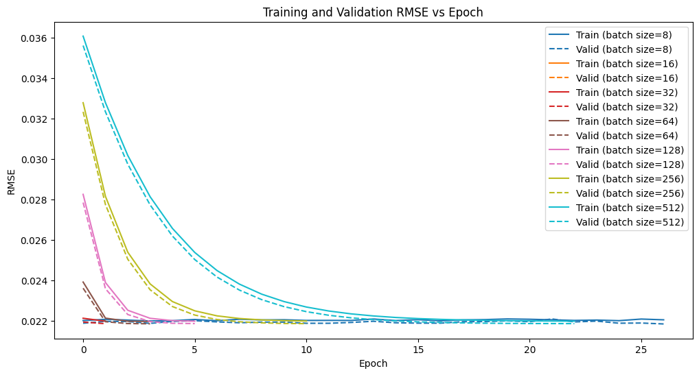

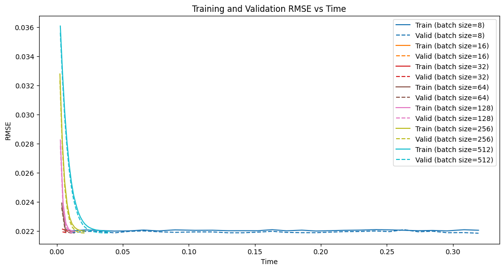

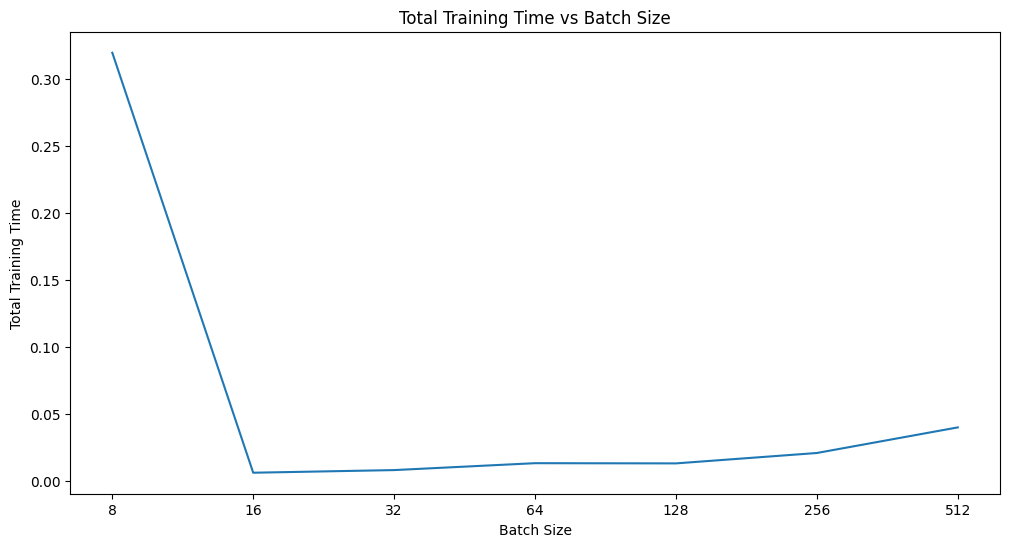

```python
import matplotlib.cm as cm

batch_sizes_conv = batch_sizes[3:]
results_conv = results[3:]
colors = cm.get_cmap('tab10', len(batch_sizes_conv))

# Plot 1: Training and Validation RMSE vs Epoch
plt.figure(figsize=(12, 6))
for i, batch_size in enumerate(batch_sizes_conv):
    rmse_train = results_conv[i][1]
    rmse_valid = results_conv[i][2]
    color = colors(i)
    plt.plot(rmse_train, label=f"Train (batch size={batch_size})", color=color)
    plt.plot(rmse_valid, label=f"Valid (batch size={batch_size})", color=color, linestyle='--')
plt.xlabel("Epoch")
plt.ylabel("RMSE")
plt.title("Training and Validation RMSE vs Epoch")
plt.legend()
plt.show()

# Plot 2: Training and Validation RMSE vs Time
plt.figure(figsize=(12, 6))
for i, batch_size in enumerate(batch_sizes_conv):
    elapsed_times = results_conv[i][3]
    rmse_train = results_conv[i][1]
    rmse_valid = results_conv[i][2]
    color = colors(i)
    plt.plot(elapsed_times, rmse_train, label=f"Train (batch size={batch_size})", color=color)
    plt.plot(elapsed_times, rmse_valid, label=f"Valid (batch size={batch_size})", color=color, linestyle='--')
plt.xlabel("Time")
plt.ylabel("RMSE")
plt.title("Training and Validation RMSE vs Time")
plt.legend()
plt.show()

# Plot 3: Total Training Time vs Batch Size
total_times = []
for result in results_conv:
    if len(result[3]) > 0:
        total_times.append(result[3][-1])
    else:
        total_times.append(0)

plt.figure(figsize=(12, 6))
plt.plot(range(len(batch_sizes_conv)), total_times)
plt.xlabel("Batch Size")
plt.ylabel("Total Training Time")
plt.title("Total Training Time vs Batch Size")
plt.xticks(range(len(batch_sizes_conv)), batch_sizes_conv)
plt.show()
```

## Part 5 - Gradient Descent Learning Rate

Use the function that you designed in Part 4 to investigate the effect of learning rate on convergence.

1. Pick 3 batch sizes that do not converge with a learning rate of $\alpha= 0.01$ (last part) and try to find a learning rate that results in convergence for each batch size. Report your findings in a table. Mention batch size, learning rate, and training and validation RMSE.
2. Select the best batch size based on Part 4's fastest convergence time and sweep the learning rate (at least 10 values, all should converge) while applying Mini-batch GD.
- Plot the training and validation RMSE vs. **epoch** (x-axis) for all the learning rates that you tried in a figure.
- Plot the training and validation RMSE vs. **time** (x-axis) for all the learning rates that you tried in a figure.
- Describe your findings, including the main takeaways from each of your plots.

In Plot 1, we can observe the RMSE of training and validation against the number of epochs for different learning rates ranging from 0.001 to 0.010. As epochs increases, RMSE consistently decreases across all learning rates, indicating model improvement. Also, higher learning rates such as 0.007, 0.008, and 0.009 achieve convergence more quickly compared to smaller learning rates like 0.001 and 0.002, which take longer to decrease.

Plot 2 illustrates RMSE vs. time, emphasizing the efficiency of training. Similar to Plot 1, larger learning rates lead to faster convergence, causing low RMSE in short time. This establishes that higher learning rates not only improve performance but also more time-efficient in this case. However, it may cause an overfitting with high learning rates.

As a result, higher learning rates for batch size 16 take shorter time and number of epochs to converge. But it has trade-offs. High learning rates may lead to overfitting because when the model converges too quickly, it may fail to predict on unseen data. It may miss the optimal solution as it overshoots during the training process. Also, this can lead to large updates to weights, making the model sensitive to noise in the training dataset instead of validation dataset.

```python
import pandas as pd

non_converge_batch_sizes = [1, 2, 4]
lr_list = [0.008, 0.005, 0.004, 0.003, 0.002]

batch_size_list = []
learning_rate_list = []
rmse_train_list = []
rmse_valid_list = []

for batch_size in non_converge_batch_sizes:
    for new_lr in lr_list:
        print(f"Batch size: {batch_size} | Learning rate: {new_lr}")
        w, rmse_train, rmse_valid, elapsed_times, is_converged = mini_batch_gd(X_train_1f, y_train, X_valid_1f, y_valid, batch_size, new_lr, ct)
        print("\n----------------------------------------\n")
        if is_converged:
            batch_size_list.append(batch_size)
            learning_rate_list.append(new_lr)
            rmse_train_list.append(rmse_train[-1])
            rmse_valid_list.append(rmse_valid[-1])
            break

df_results = pd.DataFrame({
    "Batch size": batch_size_list,
    "Learning rate": learning_rate_list,
    "Training RMSE": rmse_train_list,
    "Validation RMSE": rmse_valid_list
})

df_results.head()
```

```
Batch size: 1 | Learning rate: 0.008
Training RMSE diverges at epoch 51

----------------------------------------

Batch size: 1 | Learning rate: 0.005
Validation RMSE diverges at epoch 136

----------------------------------------

Batch size: 1 | Learning rate: 0.004
Validation RMSE converges at epoch 105

----------------------------------------

Batch size: 2 | Learning rate: 0.008
Validation RMSE converges at epoch 105

----------------------------------------

Batch size: 4 | Learning rate: 0.008
Validation RMSE converges at epoch 61

----------------------------------------
```

|  | Batch size | Learning rate | Training RMSE | Validation RMSE |
| --- | --- | --- | --- | --- |
| 0 | 1 | 0.004 | 0.022057 | 0.021854 |
| 1 | 2 | 0.008 | 0.022057 | 0.021854 |
| 2 | 4 | 0.008 | 0.022052 | 0.021856 |

```
Batch size: 16 | Learning rate: 0.001
Validation RMSE converges at epoch 7

----------------------------------------

Batch size: 16 | Learning rate: 0.002
Validation RMSE converges at epoch 3

----------------------------------------

Batch size: 16 | Learning rate: 0.003
Validation RMSE converges at epoch 3

----------------------------------------

Batch size: 16 | Learning rate: 0.004
Validation RMSE converges at epoch 1

----------------------------------------

Batch size: 16 | Learning rate: 0.005
Validation RMSE converges at epoch 1

----------------------------------------

Batch size: 16 | Learning rate: 0.006
Validation RMSE converges at epoch 0

----------------------------------------

Batch size: 16 | Learning rate: 0.007
Validation RMSE converges at epoch 0

----------------------------------------

Batch size: 16 | Learning rate: 0.008
Validation RMSE converges at epoch 0

----------------------------------------

Batch size: 16 | Learning rate: 0.009
Validation RMSE converges at epoch 0

----------------------------------------

Batch size: 16 | Learning rate: 0.010
Validation RMSE converges at epoch 0

----------------------------------------
```

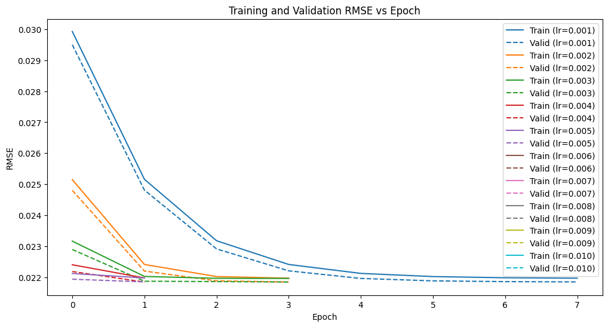

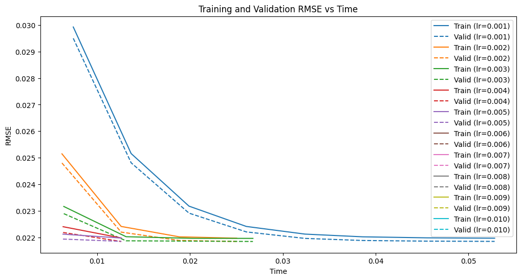

```python
lr_list = np.arange(0.001, 0.011, 0.001)
results = []
colors = cm.get_cmap('tab10', len(lr_list))

for lr in lr_list:
    print(f"Batch size: {16} | Learning rate: {lr:.3f}")
    _, rmse_train, rmse_valid, elapsed_times, _ = mini_batch_gd(X_train_1f, y_train, X_valid_1f, y_valid, 16, lr, ct)
    results.append([rmse_train, rmse_valid, elapsed_times])
    print("\n----------------------------------------\n")

# Plot 1: Training and Validation RMSE vs Epoch
plt.figure(figsize=(12, 6))
for i, lr in enumerate(lr_list):
    rmse_train = results[i][0]
    rmse_valid = results[i][1]
    color = colors(i)
    plt.plot(rmse_train, label=f"Train (lr={lr:.3f})", color=color)
    plt.plot(rmse_valid, label=f"Valid (lr={lr:.3f})", color=color, linestyle='--')
plt.xlabel("Epoch")
plt.ylabel("RMSE")
plt.title("Training and Validation RMSE vs Epoch")
plt.legend()
plt.show()

# Plot 2: Training and Validation RMSE vs Time
plt.figure(figsize=(12, 6))
for i, lr in enumerate(lr_list):
    elapsed_times = results[i][2]
    rmse_train = results[i][0]
    rmse_valid = results[i][1]
    color = colors(i)
    plt.plot(elapsed_times, rmse_train, label=f"Train (lr={lr:.3f})", color=color)
    plt.plot(elapsed_times, rmse_valid, label=f"Valid (lr={lr:.3f})", color=color, linestyle='--')
plt.xlabel("Time")
plt.ylabel("RMSE")
plt.title("Training and Validation RMSE vs Time")
plt.legend()
plt.show()
```